# US based Netflix’s Naming trend

Dec 9

Jessica Lin

## Project 2: Text Analysis

- str_*() functions and regular expressions
- Netflix Movies and TV Shows Data set
- The data set comes from Kaggle w/ credit to Shivam Bansal

```r
library("tidytuesdayR")
library("tidyverse")

netflix_titles <- readr::read_csv('https://raw.githubusercontent.com/rfordatascience/tidytuesday/master/data/2021/2021-04-20/netflix_titles.csv')

show_col_types = FALSE
```

## Shivam Bansal

- An experienced data science professional with a blend of full-stack engineering skills, pre-sales, and business skills
- A director for smaller scale video contents
- Data-sets for not just Netflix, but also many other video streaming platforms such as Amazon Prime, Disney+, and Hulu.

## Focus on US based productions

```r
library(dplyr)
library(stringr)

USfilms <- netflix_titles |>
    filter(str_detect(country, "United States")) |>
  # Filter for US-based titles
  select(title, country, type) |>
  # Select only the relevant columns
  filter(!is.na (everything))
# Remove rows with NA values in any of the selected columns
```

## Organize the data to find first character

```r
N_firstword <- USfilms |>
filter(str_detect(title, "^[A-Z]")) |>
  # Filter titles starting with uppercase letters
  mutate(first_word = str_extract(title, "^\\w")) |>
  # Extract the first word
  group_by(first_word) |> # Group by the first word
  mutate(count = n())
# Add a count of occurrences within each group

print(N_firstword)
```

```
# A tibble: 3,241 × 5
# Groups:   first_word [26]
   title                                   country        type  first_word count
   <chr>                                   <chr>          <chr> <chr>      <int>
 1 A 3 Minute Hug                          Mexico, Unite… Movie A            223
 2 A Babysitter's Guide to Monster Hunting United States  Movie A            223
 3 A Bad Moms Christmas                    United States… Movie A            223
 4 A Boy Called Po                         United States  Movie A            223
 5 A Bridge Too Far                        United States… Movie A            223
 6 A California Christmas                  United States  Movie A            223
 7 A Champion Heart                        United States  Movie A            223
 8 A Christmas Prince                      United States  Movie A            223
 9 A Christmas Prince: The Royal Baby      United States  Movie A            223
10 A Christmas Prince: The Royal Wedding   United States  Movie A            223
# ℹ 3,231 more rows
```

## ggplot

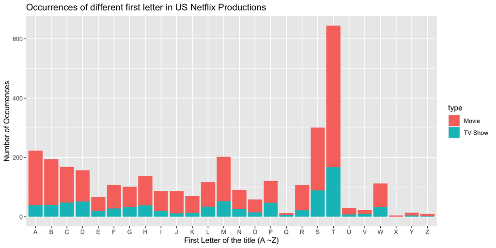

```r
library(ggplot2)

ggplot(N_firstword, aes(x= first_word, fill=type)) +
   geom_bar() +
  labs(title = "Occurrences of different first letter in US Netflix Productions",
       x = "First Letter of the title (A ~Z)",
       y = "Number of Occurrences")
```

## Organize the data to find first digit

```r
N_firstdigit <- USfilms |>
  filter(str_detect(title, "^\\d+")) |>
  # Filter titles starting with digit
  mutate(first_digit = str_extract(title, "^\\d")) |>
  # Extract the first digit
  group_by(first_digit) |> # Group by the first word
  mutate(count = n())
# Add a count of occurrences within each group

print(N_firstdigit)
```

```
# A tibble: 49 × 5
# Groups:   first_digit [8]
   title            country                        type    first_digit count
   <chr>            <chr>                          <chr>   <chr>       <int>
 1 9                United States                  Movie   9               2
 2 21               United States                  Movie   2               8
 3 187              United States                  Movie   1              21
 4 1922             United States                  Movie   1              21
 5 1983             Poland, United States          TV Show 1              21
 6 3022             United States                  Movie   3               5
 7 22-Jul           Norway, Iceland, United States Movie   2               8
 8 1 Chance 2 Dance United States                  Movie   1              21
 9 1 Mile to You    United States                  Movie   1              21
10 10,000 B.C.      United States, South Africa    Movie   1              21
# ℹ 39 more rows
```

## ggplot

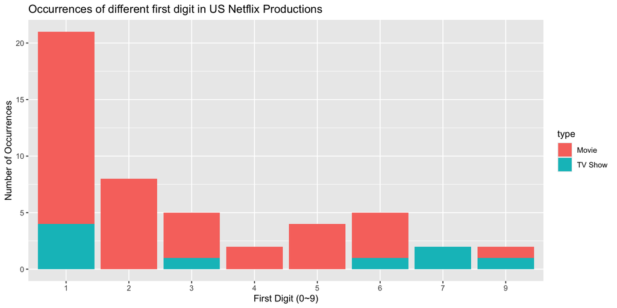

```r
 ggplot(N_firstdigit, aes(x= first_digit, fill=type)) +
   geom_bar() +
  labs(title = "Occurrences of different first digit in US Netflix Productions",
       x = "First Digit (0~9)",
       y = "Number of Occurrences")
```

## insight

The analysis of first letters in US Netflix productions reveals some intriguing patterns:

- Dominance of “T”: The letter “T” is the most common starting letter for titles. This is likely due to the prevalence of titles that begin with “The,” a common article in English.
- Prevalence of the Digit “1”: The digit “1” appears most frequently as the starting digit in both movies and TV shows.
- Absence of Titles Starting with Certain Digits: There are no TV shows starting with the digit “2” or “4,” possibly indicating a lack of popular content or marketing focus. Similarly, no movies begin with “7,” which may reflect industry naming trends or a scarcity of suitable productions.

## Benford’s Law

Benford’s Law, also known as the “law of first digits” or the “phenomenon of significant digits,” is the finding that the first digits (or numerals to be exact) of the numbers found in series of records of the most varied sources do not display a uniform distribution, but rather, they’re arranged in such a way that the digit one is the most frequent, followed by two, three, and so in a successively decreasing manner down to nine.